# Car Insurance Claim Prediction

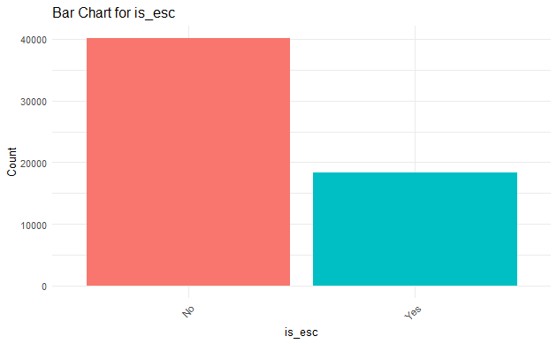

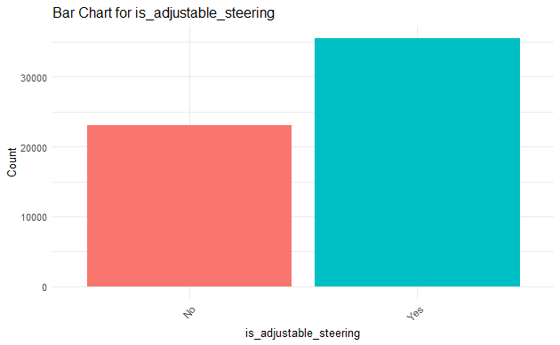

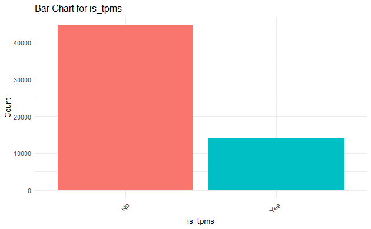

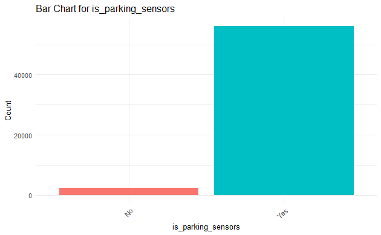

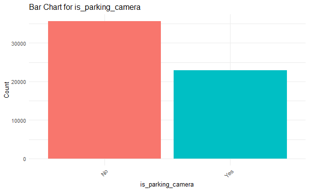

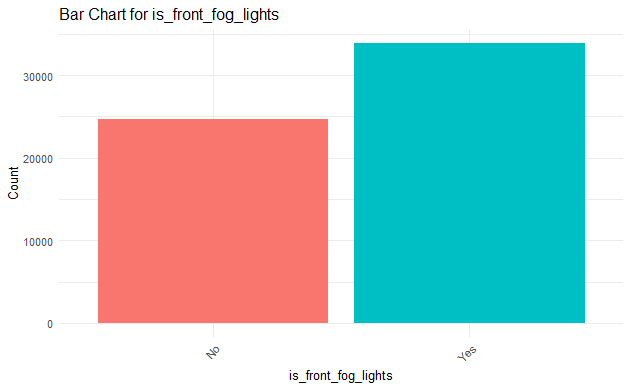

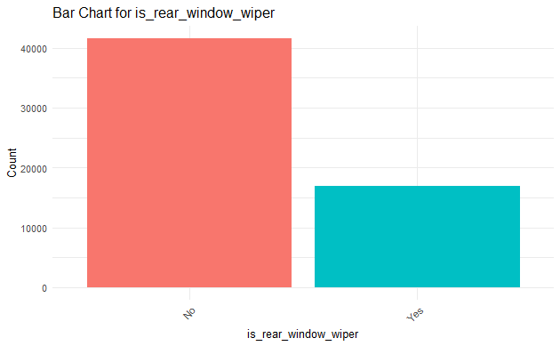

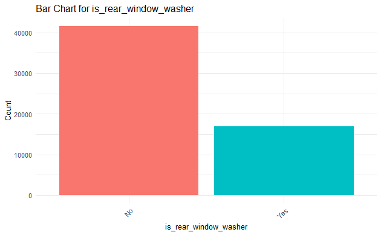

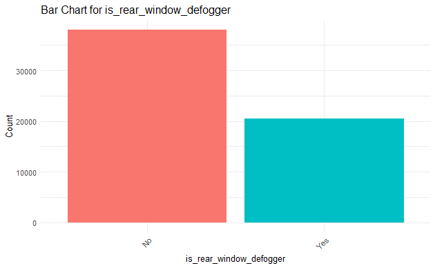

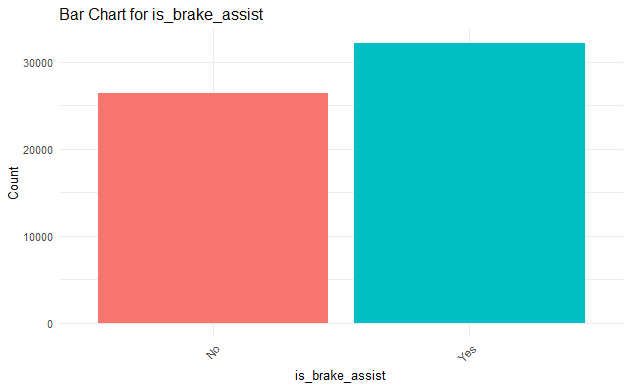

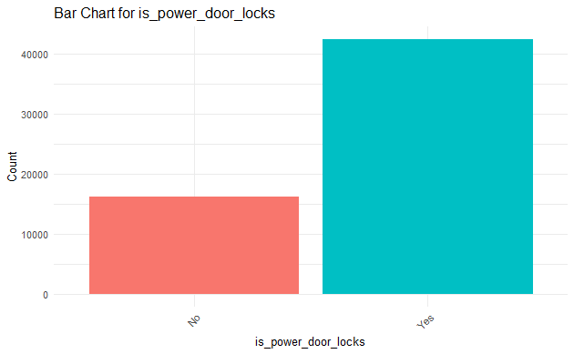

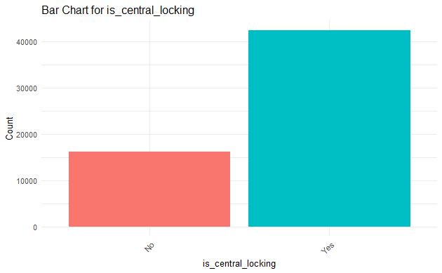

[6 more figures not shown]

There’s almost no correlation between age_of_policyholder or make and whether someone files a claim (is_claim), suggesting that no single numeric variable is a strong predictor. Because of this, simple models like linear regression might not work well. Instead, we’ll likely need to use more flexible models—like decision trees or bagging model—that can capture more complex patterns.

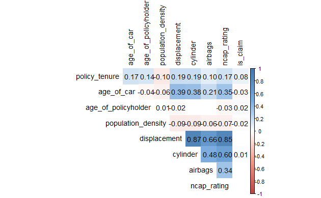

After reviewing all the visualizations, summary tables, and correlation heatmaps, I have determined which variables to keep in my predictive model and which ones to remove. My goal is to keep variables that show enough variation, offer meaningful predictive importance, and make sense in the context of insurance claims, while cutting out those that are redundant, imbalanced, or lack insight.

I’ve decided to keep numerical features like **age_of_car**, **policy_tenure**, **population_density**, **airbags**, **displacement**, **cylinder**, and **ncap_rating**. Although the correlation heatmap shows no strong linear relationship with **is_claim**, these features capture important aspects of vehicle safety, usage, and risk exposure. For example, features like **airbags** and **ncap_rating** are directly tied to crash protection, which can influence claim likelihood—especially in models like decision trees that can pick up on non-linear interactions. Similarly, **population_density** can reflect traffic conditions and accident risk, even if the correlation appears weak at first glance.

Lastly, while variables like **fuel_type**, **gear_box**, and **engine_type** bring some variety, they tend to cluster around just a few common categories. Because of that, they often overlap with more descriptive features like **displacement** or **max_power**. To keep things simple and to enhance clarity, I will focus on the variables that provide broader, more continuous understanding and eliminate the overly granular ones. Overall, I’m focused on a set of predictors that emphasize safety, vehicle complexity, and environmental exposure—without weighing the model down with noise.

# **Methodology**

Logistic Regression serves as a foundational model, offering interpretable and explainable results through its coefficients. It assumes linearity between features and the output, but helps establish a baseline for comparison. LASSO Regression enhances this model by applying L1 regularization. This technique helps prevent overfitting and automatically removes unimportant variables, making it well-suited for high-dimensional datasets with potentially redundant features. Ridge Regression uses L2 regularization, which is appropriate for multicollinearity and balances model complexity with overfitting without excluding predictors.

I will evaluate each model using accuracy, precision, recall, F1 score, and the AUC-ROC curve to address class imbalance. I will apply K-fold cross-validation for hyperparameter tuning and to ensure model generalizability. I will use backward stepwise selection for feature selection in Logistic Regression, implement regularization in LASSO, and rank variable importance from tree-based models. This multi-model methodology guarantees that I can compare performance across interpretable linear models and more flexible ensemble models

# **Results**

### **Logistic Regression Model**

Upon reviewing the model’s performance, I realized that relying only on the typical accuracy metric would not provide an accurate evaluation. Even with great accuracy of 93.6% across various thresholds, this figure was somewhat misleading, as the model predominantly predicted non-claims due to the significant class imbalance. To gain a better idea of the model’s effectiveness, I experimented with different classification thresholds ranging from 0.1 to 0.9. Throughout this process, I focused on essential metrics such as sensitivity, specificity, precision, recall, F1 score, and AUC to evaluate its true performance.

```
Call:
glm(formula = is_claim ~ ., family = "binomial", data = train_clean)

Coefficients:
                     Estimate Std. Error z value Pr(>|z|)
(Intercept)        -3.993e+00  4.004e-01  -9.970  < 2e-16 ***
age_of_car         -3.904e+00  4.028e-01  -9.692  < 2e-16 ***
policy_tenure       8.145e-01  4.910e-02  16.589  < 2e-16 ***
population_density -3.712e-06  1.166e-06  -3.183  0.00146 **
airbags             6.607e-02  4.736e-02   1.395  0.16305
displacement       -1.739e-03  1.065e-03  -1.634  0.10225
cylinder            7.645e-01  3.754e-01   2.036  0.04170 *
ncap_rating         1.414e-01  8.394e-02   1.685  0.09207 .
is_esc              8.057e-02  1.515e-01   0.532  0.59498
is_tpms             2.642e-02  1.357e-01   0.195  0.84565
is_parking_camera  -3.243e-02  9.898e-02  -0.328  0.74318
is_brake_assist    -2.485e-01  1.414e-01  -1.757  0.07893 .
---
Signif. codes:  0 ‘***’ 0.001 ‘**’ 0.01 ‘*’ 0.05 ‘.’ 0.1 ‘ ’ 1

(Dispersion parameter for binomial family taken to be 1)

    Null deviance: 22292  on 46873  degrees of freedom
Residual deviance: 21898  on 46862  degrees of freedom
AIC: 21922

Number of Fisher Scoring iterations: 5
```

|  | Threshold | Accuracy.Accuracy | Recall.Sensitivity | Specificity.Specificity | Precision.Pos Pred Value | F1.Pos Pred Value | Balanced_Accuracy.Balanced Accuracy | AUC |
| --- | --- | --- | --- | --- | --- | --- | --- | --- |
| 0.1 | 0.1 | 0.8727 | 0.9242 | 0.1175 | 0.9388 | 0.9315 | 0.5209 | 0.6121 |
| 0.2 | 0.2 | 0.9361 | 1.0000 | 0.0000 | 0.9361 | 0.9670 | 0.5000 | 0.6121 |
| 0.3 | 0.3 | 0.9361 | 1.0000 | 0.0000 | 0.9361 | 0.9670 | 0.5000 | 0.6121 |
| 0.4 | 0.4 | 0.9361 | 1.0000 | 0.0000 | 0.9361 | 0.9670 | 0.5000 | 0.6121 |
| 0.5 | 0.5 | 0.9361 | 1.0000 | 0.0000 | 0.9361 | 0.9670 | 0.5000 | 0.6121 |
| 0.6 | 0.6 | 0.9361 | 1.0000 | 0.0000 | 0.9361 | 0.9670 | 0.5000 | 0.6121 |
| 0.7 | 0.7 | 0.9361 | 1.0000 | 0.0000 | 0.9361 | 0.9670 | 0.5000 | 0.6121 |
| 0.8 | 0.8 | 0.9361 | 1.0000 | 0.0000 | 0.9361 | 0.9670 | 0.5000 | 0.6121 |
| 0.9 | 0.9 | 0.9361 | 1.0000 | 0.0000 | 0.9361 | 0.9670 | 0.5000 | 0.6121 |

```
Best threshold based on Balanced Accuracy: 0.1
Confusion Matrix and Statistics

          Reference
Prediction     0     1
         0 10138   661
         1   831    88

               Accuracy : 0.8727
                 95% CI : (0.8665, 0.8787)
    No Information Rate : 0.9361
    P-Value [Acc > NIR] : 1

                  Kappa : 0.0377

 Mcnemar's Test P-Value : 1.213e-05

            Sensitivity : 0.92424
            Specificity : 0.11749
         Pos Pred Value : 0.93879
         Neg Pred Value : 0.09576
             Prevalence : 0.93608
         Detection Rate : 0.86516
   Detection Prevalence : 0.92157
      Balanced Accuracy : 0.52087

       'Positive' Class : 0
```

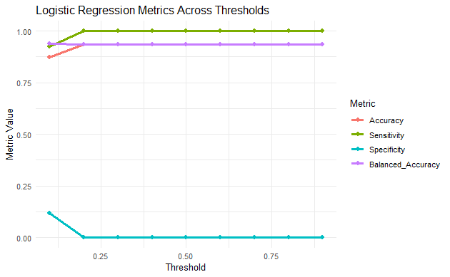

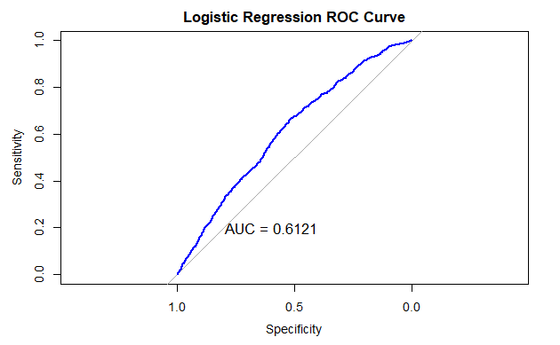

### **Logistic Regression with Backward Stepwise Selected Features**

|  | Threshold | Accuracy.Accuracy | Recall.Sensitivity | Specificity.Specificity | Precision.Pos Pred Value | F1.Pos Pred Value | Balanced_Accuracy.Balanced Accuracy | AUC |
| --- | --- | --- | --- | --- | --- | --- | --- | --- |
| 0.1 | 0.1 | 0.8725 | 0.1148 | 0.9242 | 0.0938 | 0.1032 | 0.5195 | 0.6113 |
| 0.2 | 0.2 | 0.9361 | 0.0000 | 1.0000 | NaN | 0.0000 | 0.5000 | 0.6113 |
| 0.3 | 0.3 | 0.9361 | 0.0000 | 1.0000 | NaN | 0.0000 | 0.5000 | 0.6113 |
| 0.4 | 0.4 | 0.9361 | 0.0000 | 1.0000 | NaN | 0.0000 | 0.5000 | 0.6113 |
| 0.5 | 0.5 | 0.9361 | 0.0000 | 1.0000 | NaN | 0.0000 | 0.5000 | 0.6113 |
| 0.6 | 0.6 | 0.9361 | 0.0000 | 1.0000 | NaN | 0.0000 | 0.5000 | 0.6113 |
| 0.7 | 0.7 | 0.9361 | 0.0000 | 1.0000 | NaN | 0.0000 | 0.5000 | 0.6113 |
| 0.8 | 0.8 | 0.9361 | 0.0000 | 1.0000 | NaN | 0.0000 | 0.5000 | 0.6113 |
| 0.9 | 0.9 | 0.9361 | 0.0000 | 1.0000 | NaN | 0.0000 | 0.5000 | 0.6113 |

```
Best threshold based on Balanced Accuracy: 0.1
Confusion Matrix and Statistics

          Reference
Prediction     0     1
         0 10138   663
         1   831    86

               Accuracy : 0.8725
                 95% CI : (0.8663, 0.8785)
    No Information Rate : 0.9361
    P-Value [Acc > NIR] : 1

                  Kappa : 0.0354

 Mcnemar's Test P-Value : 1.556e-05

            Sensitivity : 0.92424
            Specificity : 0.11482
         Pos Pred Value : 0.93862
         Neg Pred Value : 0.09378
             Prevalence : 0.93608
         Detection Rate : 0.86516
   Detection Prevalence : 0.92174
      Balanced Accuracy : 0.51953

       'Positive' Class : 0
```

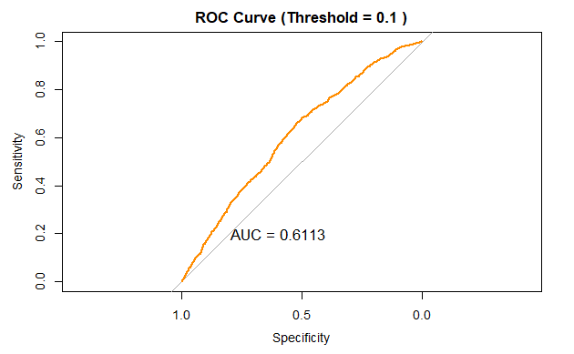

The logistic regression model using backward stepwise selection below identifies several statistically significant predictors of whether a policyholder will file a claim. Policy_tenure has a highly significant and positive coefficient, indicating that long-standing customers are more likely to file a claim. This may seem counterintuitive but could reflect factors such as increased vehicle usage or a greater likelihood of claim awareness over time.

In terms of vehicle specifications, displacement is negatively associated with claims, meaning vehicles with larger engine displacement are slightly less likely to be involved in claims. Cylinder count, on the other hand, has a positive and statistically significant coefficient, implying that cars with more cylinders may possess a higher risk, perhaps due to being more performance-oriented or driven differently. Other variables like ncap_rating, airbags, and is_brake_assist demonstrate weaker significance levels but may still provide predictive value and should be considered alongside other features or tested in further models.

```
Call:
glm(formula = is_claim ~ age_of_car + policy_tenure + population_density +
    airbags + displacement + cylinder + ncap_rating + is_brake_assist,
    family = binomial, data = train_clean)

Coefficients:
                     Estimate Std. Error z value Pr(>|z|)
(Intercept)        -3.965e+00  3.523e-01 -11.254  < 2e-16 ***
age_of_car         -3.919e+00  3.995e-01  -9.810  < 2e-16 ***
policy_tenure       8.125e-01  4.890e-02  16.615  < 2e-16 ***
population_density -3.707e-06  1.166e-06  -3.179  0.00148 **
airbags             7.735e-02  4.246e-02   1.822  0.06850 .
displacement       -1.643e-03  8.200e-04  -2.004  0.04509 *
cylinder            7.212e-01  2.830e-01   2.548  0.01084 *
ncap_rating         1.342e-01  7.361e-02   1.823  0.06837 .
is_brake_assist    -2.196e-01  1.187e-01  -1.851  0.06421 .
---
Signif. codes:  0 ‘***’ 0.001 ‘**’ 0.01 ‘*’ 0.05 ‘.’ 0.1 ‘ ’ 1

(Dispersion parameter for binomial family taken to be 1)

    Null deviance: 22292  on 46873  degrees of freedom
Residual deviance: 21899  on 46865  degrees of freedom
AIC: 21917

Number of Fisher Scoring iterations: 5
```

### **LASSO Logistic Regression**

Based on the outputs from the LASSO regression model below, similar performance patterns emerge as observed in the previous logistic regression models. The model’s AUC of 0.6114 indicates that it performs better than random guessing when distinguishing between claimants and non-claimants. At the optimal threshold of 0.1, LASSO achieved an accuracy of 88.2%, sensitivity of 93.5%, and specificity of 11.1%. The high sensitivity reveals that the model effectively identifies most non-claimants, who dominate the dataset, but struggles to identify true claimants (specificity) due to its low performance.

The precision and F1 score at this threshold—0.9390 and 0.1074 respectively—indicate that while the model makes a meaningful number of correct positive predictions, the low F1 score reflects the difficulties presented by the imbalance in class representation. At higher thresholds (0.2 and beyond), LASSO fails to identify any claimants, resulting in NaN values for precision and F1. This outcome stems from the model predicts all observations as non-claimants As with logistic regression, threshold adjustment was essential to enhance the model’s usefulness, especially in identifying the minority class. LASSO’s advantage is its automatic feature selection via regularization, which controls overfitting and improves generalizability, but it still struggles with class imbalance.

|  | Threshold | Accuracy.Accuracy | Recall.Sensitivity | Specificity.Specificity | Precision.Pos Pred Value | F1.Pos Pred Value | Balanced_Accuracy.Balanced Accuracy | AUC |
| --- | --- | --- | --- | --- | --- | --- | --- | --- |
| 0.1 | 0.1 | 0.8823 | 0.1108 | 0.935 | 0.1043 | 0.1074 | 0.5229 | 0.6114 |
| 0.2 | 0.2 | 0.9361 | 0.0000 | 1.000 | NaN | NA | 0.5000 | 0.6114 |
| 0.3 | 0.3 | 0.9361 | 0.0000 | 1.000 | NaN | NA | 0.5000 | 0.6114 |
| 0.4 | 0.4 | 0.9361 | 0.0000 | 1.000 | NaN | NA | 0.5000 | 0.6114 |
| 0.5 | 0.5 | 0.9361 | 0.0000 | 1.000 | NaN | NA | 0.5000 | 0.6114 |
| 0.6 | 0.6 | 0.9361 | 0.0000 | 1.000 | NaN | NA | 0.5000 | 0.6114 |
| 0.7 | 0.7 | 0.9361 | 0.0000 | 1.000 | NaN | NA | 0.5000 | 0.6114 |
| 0.8 | 0.8 | 0.9361 | 0.0000 | 1.000 | NaN | NA | 0.5000 | 0.6114 |
| 0.9 | 0.9 | 0.9361 | 0.0000 | 1.000 | NaN | NA | 0.5000 | 0.6114 |

```
Best threshold based on Balanced Accuracy: 0.1
Confusion Matrix and Statistics

          Reference
Prediction     0     1
         0 10256   666
         1   713    83

               Accuracy : 0.8823
                 95% CI : (0.8763, 0.8881)
    No Information Rate : 0.9361
    P-Value [Acc > NIR] : 1.0000

                  Kappa : 0.0445

 Mcnemar's Test P-Value : 0.2154

            Sensitivity : 0.9350
            Specificity : 0.1108
         Pos Pred Value : 0.9390
         Neg Pred Value : 0.1043
             Prevalence : 0.9361
         Detection Rate : 0.8752
   Detection Prevalence : 0.9321
      Balanced Accuracy : 0.5229

       'Positive' Class : 0
```

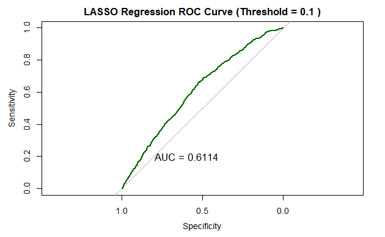

### **Ridge Regression with Backward Stepwise Selected Features**

```
Best threshold based on Balanced Accuracy: 0.1
Confusion Matrix and Statistics

          Reference
Prediction     0     1
         0 10249   668
         1   720    81

               Accuracy : 0.8815
                 95% CI : (0.8756, 0.8873)
    No Information Rate : 0.9361
    P-Value [Acc > NIR] : 1.000

                  Kappa : 0.0412

 Mcnemar's Test P-Value : 0.171

            Sensitivity : 0.9344
            Specificity : 0.1081
         Pos Pred Value : 0.9388
         Neg Pred Value : 0.1011
             Prevalence : 0.9361
         Detection Rate : 0.8746
   Detection Prevalence : 0.9316
      Balanced Accuracy : 0.5213

       'Positive' Class : 0
```

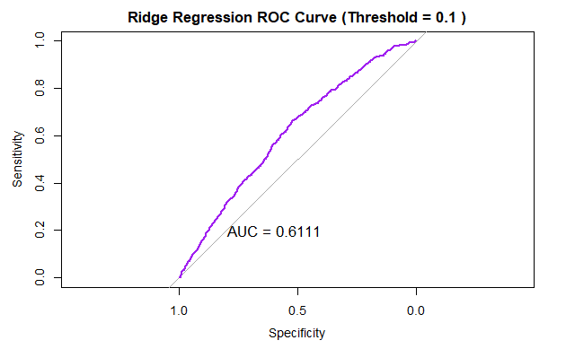

### **Random Forest**

Despite achieving a high overall accuracy of 93.3%, the Random Forest model struggles to detect actual claims due to its low sensitivity. With a sensitivity of just 0.0067, the model correctly identified fewer than 1% of claimants. On the other hand, the specificity was 0.996, reflecting strong performance in identifying non-claimants. However, due to the imbalance in the dataset, this leads to a distorted picture of performance. The balanced accuracy, which averages sensitivity and specificity, was only 0.501, underscoring the model’s difficulty in handling the minority class.

The AUC of 0.511 further supports this finding, indicating the model’s inability to separate claimants from non-claimants. Additionally, at higher thresholds, most precision and F1 score values returned as NaN, which occurs when no positive cases are predicted rendering those metrics undefined. These outcomes emphasize that while the model appears effective in aggregate terms, it performs poorly when the focus shifts to detecting actual claims.

|  | Threshold | Accuracy.Accuracy | Recall.Sensitivity | Specificity.Specificity | Precision.Pos Pred Value | F1.Pos Pred Value | Balanced_Accuracy.Balanced Accuracy | AUC |
| --- | --- | --- | --- | --- | --- | --- | --- | --- |
| 0.1 | 0.1 | 0.9327 | 0.0067 | 0.9959 | 0.1 | 0.0125 | 0.5013 | 0.5114 |
| 0.2 | 0.2 | 0.9357 | 0.0000 | 0.9995 | 0.0 | NA | 0.4998 | 0.5114 |
| 0.3 | 0.3 | 0.9361 | 0.0000 | 1.0000 | NaN | NA | 0.5000 | 0.5114 |
| 0.4 | 0.4 | 0.9361 | 0.0000 | 1.0000 | NaN | NA | 0.5000 | 0.5114 |
| 0.5 | 0.5 | 0.9361 | 0.0000 | 1.0000 | NaN | NA | 0.5000 | 0.5114 |
| 0.6 | 0.6 | 0.9361 | 0.0000 | 1.0000 | NaN | NA | 0.5000 | 0.5114 |
| 0.7 | 0.7 | 0.9361 | 0.0000 | 1.0000 | NaN | NA | 0.5000 | 0.5114 |
| 0.8 | 0.8 | 0.9361 | 0.0000 | 1.0000 | NaN | NA | 0.5000 | 0.5114 |
| 0.9 | 0.9 | 0.9361 | 0.0000 | 1.0000 | NaN | NA | 0.5000 | 0.5114 |

```
Best threshold based on Balanced Accuracy: 0.1
Confusion Matrix and Statistics

          Reference
Prediction     0     1
         0 10924   744
         1    45     5

               Accuracy : 0.9327
                 95% CI : (0.928, 0.9371)
    No Information Rate : 0.9361
    P-Value [Acc > NIR] : 0.936

                  Kappa : 0.0046

 Mcnemar's Test P-Value : <2e-16

            Sensitivity : 0.0066756
            Specificity : 0.9958975
         Pos Pred Value : 0.1000000
         Neg Pred Value : 0.9362359
             Prevalence : 0.0639188
         Detection Rate : 0.0004267
   Detection Prevalence : 0.0042669
      Balanced Accuracy : 0.5012865

       'Positive' Class : 1
```

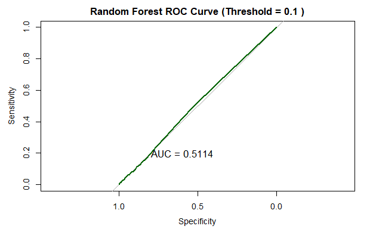

A variable importance plot was developed to provide deeper insights into each predictor’s impact. According to the Mean Decrease in Gini, policy_tenure stood out as the most significant variable, followed by age_of_car and population_density. These findings confirm earlier models, strengthening the hypothesis that experience, vehicle age, and regional factors significantly influence claim risk.

```
                   MeanDecreaseGini
age_of_car               137.724918
policy_tenure            382.541771
population_density        98.411601
airbags                    6.499799
displacement              21.380849
cylinder                   6.403969
ncap_rating               16.823926
is_esc                     5.295741
is_tpms                    2.946551
is_parking_camera          8.860456
is_brake_assist            5.761968
```

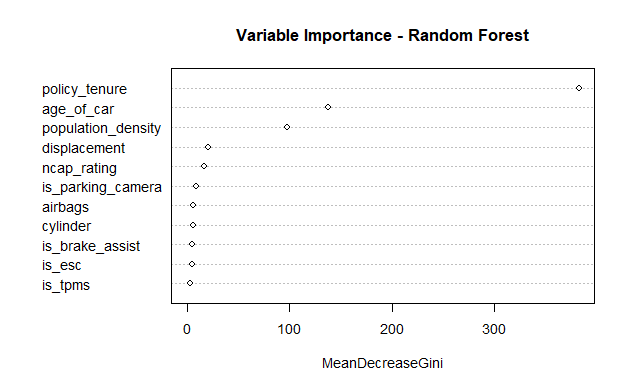

# **Conclusions**

# **Discussion**

This project presented a combination of challenges and learning experinces. One of the most difficult aspects was the data preparation, especially the challenges encountered in encoding and factoring certain variables. Many features initially returned NaN values during modeling, which led to days of troubleshooting. In the end, I restarted the process entirely, which was necessary to address the persistent issues and ultimately helped me clean and structure the data more effectively. Additionally, understanding the automotive context of many variables proved time consuming. I spent significant time researching what terms like displacement, ncap_rating, and cylinder meant and how they related to vehicle safety or performance.

I enjoyed validating my model outputs. At one point, I worried that I had misapplied modeling techniques, but through exploration and evaluation, I realized that the real challenge stemmed from the class imbalance in the dataset—not a modeling error. This deepened my appreciation for metrics like recall, F1 score, and balanced accuracy. Given more time, I would have explored more advanced ensemble techniques like XGBoost and Gradient Boosting, or compared results with a Support Vector Machine to determine if these methods could handle the class imbalance more effectively.

# **References**

- https://www.kaggle.com/datasets/ifteshanajnin/carinsuranceclaimprediction-classification
- https://www.analyticsvidhya.com/datahack/contest/dataverse/